# Отток клиентов

Из «Бета-Банка» стали уходить клиенты. Каждый месяц. Немного, но заметно. Банковские маркетологи посчитали: сохранять текущих клиентов дешевле, чем привлекать новых. Нужно спрогнозировать, уйдёт клиент из банка в ближайшее время или нет. Источник данных: https://www.kaggle.com/barelydedicated/bank-customer-churn-modeling

## Подготовка данных

```python
import pandas as pd
import numpy as np
from sklearn.tree import DecisionTreeClassifier
from sklearn.ensemble import RandomForestClassifier
from sklearn.linear_model import LogisticRegression
from sklearn.metrics import f1_score
from sklearn.metrics import roc_auc_score
from sklearn.metrics import precision_score, recall_score
from sklearn.model_selection import train_test_split
from sklearn.preprocessing import StandardScaler
from sklearn.utils import shuffle
from sklearn.metrics import roc_curve
import matplotlib.pyplot as plt
```

```python
#выберем переменную для значения random_state
rand = 123
```

```python
data = pd.read_csv('C:\\Users\\elena\\Documents\\git_projects\\Churn_Modelling.csv', sep=',')
```

```python
data.info()
```

```
<class 'pandas.core.frame.DataFrame'>
RangeIndex: 10000 entries, 0 to 9999
Data columns (total 14 columns):
 #   Column           Non-Null Count  Dtype
---  ------           --------------  -----
 0   RowNumber        10000 non-null  int64
 1   CustomerId       10000 non-null  int64
 2   Surname          10000 non-null  object
 3   CreditScore      10000 non-null  int64
 4   Geography        10000 non-null  object
 5   Gender           10000 non-null  object
 6   Age              10000 non-null  int64
 7   Tenure           10000 non-null  int64
 8   Balance          10000 non-null  float64
 9   NumOfProducts    10000 non-null  int64
 10  HasCrCard        10000 non-null  int64
 11  IsActiveMember   10000 non-null  int64
 12  EstimatedSalary  10000 non-null  float64
 13  Exited           10000 non-null  int64
dtypes: float64(2), int64(9), object(3)
memory usage: 1.1+ MB
```

```python
data.Tenure.describe()
```

```
count    10000.000000
mean         5.012800
std          2.892174
min          0.000000
25%          3.000000
50%          5.000000
75%          7.000000
max         10.000000
Name: Tenure, dtype: float64
```

```python
data.Tenure = data.Tenure.fillna(data.Tenure.mean())
```

```python
data.head()
```

|  | RowNumber | CustomerId | Surname | CreditScore | Geography | Gender | Age | Tenure | Balance | NumOfProducts | HasCrCard | IsActiveMember | EstimatedSalary | Exited |
| --- | --- | --- | --- | --- | --- | --- | --- | --- | --- | --- | --- | --- | --- | --- |
| 0 | 1 | 15634602 | Hargrave | 619 | France | Female | 42 | 2 | 0.00 | 1 | 1 | 1 | 101348.88 | 1 |
| 1 | 2 | 15647311 | Hill | 608 | Spain | Female | 41 | 1 | 83807.86 | 1 | 0 | 1 | 112542.58 | 0 |
| 2 | 3 | 15619304 | Onio | 502 | France | Female | 42 | 8 | 159660.80 | 3 | 1 | 0 | 113931.57 | 1 |
| 3 | 4 | 15701354 | Boni | 699 | France | Female | 39 | 1 | 0.00 | 2 | 0 | 0 | 93826.63 | 0 |
| 4 | 5 | 15737888 | Mitchell | 850 | Spain | Female | 43 | 2 | 125510.82 | 1 | 1 | 1 | 79084.10 | 0 |

```python
#проверим наличие дублей в данных
data.duplicated().sum()
```

```
0
```

```python
#разделим данные на целевой показатель и признаки, опустив при разбиении столбцы, ненужные модели для обучения
target = data['Exited']
features = data.drop(['Exited', 'RowNumber', 'CustomerId', 'Surname'], axis=1)
```

```python
#заменим категориальные признаки на численные техникой OHE
features_ohe = pd.get_dummies(features)
```

```python
features_ohe.head()
```

|  | CreditScore | Age | Tenure | Balance | NumOfProducts | HasCrCard | IsActiveMember | EstimatedSalary | Geography_France | Geography_Germany | Geography_Spain | Gender_Female | Gender_Male |
| --- | --- | --- | --- | --- | --- | --- | --- | --- | --- | --- | --- | --- | --- |
| 0 | 619 | 42 | 2 | 0.00 | 1 | 1 | 1 | 101348.88 | 1 | 0 | 0 | 1 | 0 |
| 1 | 608 | 41 | 1 | 83807.86 | 1 | 0 | 1 | 112542.58 | 0 | 0 | 1 | 1 | 0 |
| 2 | 502 | 42 | 8 | 159660.80 | 3 | 1 | 0 | 113931.57 | 1 | 0 | 0 | 1 | 0 |
| 3 | 699 | 39 | 1 | 0.00 | 2 | 0 | 0 | 93826.63 | 1 | 0 | 0 | 1 | 0 |
| 4 | 850 | 43 | 2 | 125510.82 | 1 | 1 | 1 | 79084.10 | 0 | 0 | 1 | 1 | 0 |

## Исследование задачи

Разобьем данные на 3 выборки: тренировочную, валидационную и тестовую, в пропорции 6:2:2

```python
features_train, features_temp, target_train, target_temp = train_test_split(features_ohe, target, test_size=0.4, random_state=rand)
features_valid, features_test, target_valid, target_test = train_test_split(features_temp, target_temp, test_size=0.5, random_state=rand)
```

```python
print(features_train.shape)
print(features_valid.shape)
print(features_test.shape)
```

```
(6000, 13)
(2000, 13)
(2000, 13)
```

```python
#приведем численные признаки к одинаковому масштабу
numeric = ['CreditScore', 'Age', 'Balance', 'NumOfProducts', 'EstimatedSalary']
scaler = StandardScaler()
scaler.fit(features_train[numeric])
features_train[numeric] = scaler.transform(features_train[numeric])
features_valid[numeric] = scaler.transform(features_valid[numeric])
features_test[numeric] = scaler.transform(features_test[numeric])
```

```python
classification_models = [DecisionTreeClassifier(random_state=rand),
                         RandomForestClassifier(random_state=rand),
                         LogisticRegression(random_state=rand, solver='liblinear')]
```

```python
for model in classification_models:
    model = model
    model.fit(features_train, target_train)
    predictions = model.predict(features_valid)
    print("Модель")
    print(model)
    print("F1 на валидационной выборке: ", f1_score(target_valid, predictions))
```

```
Модель
DecisionTreeClassifier(random_state=123)
F1 на валидационной выборке:  0.4963503649635037
Модель
RandomForestClassifier(random_state=123)
F1 на валидационной выборке:  0.575516693163752
Модель
LogisticRegression(random_state=123, solver='liblinear')
F1 на валидационной выборке:  0.28787878787878785
```

По результатам видно, что наилучшее значение метрики f1 показывает модель случайного леса, подберем гиперпараметры для леса и для дерева решений.

```python
#подберем наилучшие гиперпараметры глубины для модели случайного леса
best_model_tree = None
best_result_tree = 0
best_result_auc = 0
for i in range(1,25):
    model = RandomForestClassifier(max_depth = i, random_state=rand)
    model.fit(features_train, target_train)
    predictions = model.predict(features_valid)
    probabilities_valid = model.predict_proba(features_valid)
    probabilities_one_valid = probabilities_valid[:, 1]
    result = f1_score(target_valid, predictions)
    result_1 = roc_auc_score(target_valid, probabilities_one_valid)
    if result > best_result_tree:
        #if result_1 > best_result_auc:
            best_model_tree = model
            best_result_tree = result
            best_result_auc = result_1
print('Лучшая модель леса: {}'.format(best_model_tree))
print('Лучшее значение f1: {}'.format(best_result_tree))
#print('Лучшее значение roc_auc: {}'.format(best_result_auc))
```

```
Лучшая модель леса: RandomForestClassifier(max_depth=24, random_state=123)
Лучшее значение f1: 0.5813586097946287
```

```python
#подберем наилучшие гиперпараметры количества деревьев для модели случайного леса
best_model_tree = None
best_result_tree = 0
best_result_auc = 0
for i in range(5,100):
    model = RandomForestClassifier(n_estimators = i, max_depth = 19, random_state=rand)
    model.fit(features_train, target_train)
    predictions = model.predict(features_valid)
    probabilities_valid = model.predict_proba(features_valid)
    probabilities_one_valid = probabilities_valid[:, 1]
    result = f1_score(target_valid, predictions)
    result_1 = roc_auc_score(target_valid, probabilities_one_valid)
    if result > best_result_tree:
        #if result_1 > best_result_auc:
            best_model_tree = model
            best_result_tree = result
            best_result_auc = result_1
print('Лучшая модель леса: {}'.format(best_model_tree))
print('Лучшее значение f1: {}'.format(best_result_tree))
#print('Лучшее значение roc_auc: {}'.format(best_result_auc))
```

```
Лучшая модель леса: RandomForestClassifier(max_depth=19, n_estimators=49, random_state=123)
Лучшее значение f1: 0.5943396226415094
```

```python
#подберем наилучшие гиперпараметры глубины для модели дерева решений
best_model_tree = None
best_result_tree = 0
best_result_auc = 0
for i in range(1,11):
    model = DecisionTreeClassifier(max_depth = i, random_state=rand)
    model.fit(features_train, target_train)
    predictions = model.predict(features_valid)
    probabilities_valid = model.predict_proba(features_valid)
    probabilities_one_valid = probabilities_valid[:, 1]
    result = f1_score(target_valid, predictions)
    result_1 = roc_auc_score(target_valid, probabilities_one_valid)
    if result > best_result_tree:
        #if result_1 > best_result_auc:
            best_model_tree = model
            best_result_tree = result
            best_result_auc = result_1
print('Лучшая модель леса: {}'.format(best_model_tree))
print('Лучшее значение f1: {}'.format(best_result_tree))
#print('Лучшее значение roc_auc: {}'.format(best_result_auc))
```

```
Лучшая модель леса: DecisionTreeClassifier(max_depth=7, random_state=123)
Лучшее значение f1: 0.5723270440251572
```

Лучшим параметром для дерева решений явялется max_depth=7. Значение меры f1 дерева решений не превышает значение, полученное другими моделями.

## Борьба с дисбалансом

```python
#исследуем баланс классов
target_train.value_counts()
```

```
0    4761
1    1239
Name: Exited, dtype: int64
```

```python
def upsample(features, target, repeat):
    features_zeros = features[target == 0]
    features_ones = features[target == 1]
    target_zeros = target[target == 0]
    target_ones = target[target == 1]

    features_upsampled = pd.concat([features_zeros] + [features_ones] * repeat)
    target_upsampled = pd.concat([target_zeros] + [target_ones] * repeat)

    features_upsampled, target_upsampled = shuffle(
        features_upsampled, target_upsampled, random_state=rand)

    return features_upsampled, target_upsampled

features_upsampled, target_upsampled = upsample(features_train, target_train, 3)
```

```python
#проверим значения метрик после восстановления баланса методом upsampling валидационной выборке
best_model_tree = None
best_result_tree = 0
best_result_auc = 0
for i in range(1,30):
    model = RandomForestClassifier(max_depth = i, random_state=rand)
    model.fit(features_upsampled, target_upsampled)
    predictions = model.predict(features_valid)
    probabilities_valid = model.predict_proba(features_valid)
    probabilities_one_valid = probabilities_valid[:, 1]
    result = f1_score(target_valid, predictions)
    result_1 = roc_auc_score(target_valid, probabilities_one_valid)
    if result > best_result_tree:
        #if result_1 > best_result_auc:
            best_model_tree = model
            best_result_tree = result
            best_result_auc = result_1
print('Лучшая модель леса: {}'.format(best_model_tree))
print('Лучшее значение f1: {}'.format(best_result_tree))
print('значение roc_auc: {}'.format(best_result_auc))
```

```
Лучшая модель леса: RandomForestClassifier(max_depth=9, random_state=123)
Лучшее значение f1: 0.6341463414634148
значение roc_auc: 0.864021973437174
```

```python
#подберем наилучшие гиперпараметры количества деревьев для модели случайного леса
best_model_tree = None
best_result_tree = 0
best_result_auc = 0
for i in range(5,100):
    model = RandomForestClassifier(max_depth = 8, n_estimators=i, random_state=rand)
    model.fit(features_upsampled, target_upsampled)
    predictions = model.predict(features_valid)
    probabilities_valid = model.predict_proba(features_valid)
    probabilities_one_valid = probabilities_valid[:, 1]
    result = f1_score(target_valid, predictions)
    result_1 = roc_auc_score(target_valid, probabilities_one_valid)
    if result > best_result_tree:
        #if result_1 > best_result_auc:
            best_model_tree = model
            best_result_tree = result
            best_result_auc = result_1
print('Лучшая модель леса: {}'.format(best_model_tree))
print('Лучшее значение f1: {}'.format(best_result_tree))
print('значение roc_auc: {}'.format(best_result_auc))
```

```
Лучшая модель леса: RandomForestClassifier(max_depth=8, n_estimators=51, random_state=123)
Лучшее значение f1: 0.6323353293413173
значение roc_auc: 0.8616656446953365
```

```python
#проверим значения метрик после восстановления баланса, указав аргумент class_weight
model = RandomForestClassifier(max_depth = 8, n_estimators=51, random_state=rand, class_weight='balanced')
model.fit(features_train, target_train)
predictions = model.predict(features_valid)
probabilities_valid = model.predict_proba(features_valid)
probabilities_one_valid = probabilities_valid[:, 1]
result = f1_score(target_valid, predictions)
result_1 = roc_auc_score(target_valid, probabilities_one_valid)
print('Значение F1: {}'.format(result))
print('Значение ROC-AUC: {}'.format(result_1))
```

```
Значение F1: 0.6111111111111112
Значение ROC-AUC: 0.8581414239748153
```

Значение метрики f1 и значение roc_auc уменьшилось.

```python
#протестируем изменение порога классификации
model = RandomForestClassifier(max_depth = 8, n_estimators=51, random_state=rand)
model.fit(features_upsampled, target_upsampled)
probabilities_valid = model.predict_proba(features_valid)
probabilities_one_valid = probabilities_valid[:, 1]


for threshold in np.arange(0, 0.8, 0.02):
    predicted_valid = probabilities_one_valid > threshold
    result = f1_score(target_valid, predicted_valid)
    result_1 = roc_auc_score(target_valid, predicted_valid)
    precision = precision_score(target_valid, predicted_valid)
    recall = recall_score(target_valid, predicted_valid)

    print("Порог = {:.2f} | F1 мера = {:.3f}, ROC-AUC = {:.3f}, точность = {:.2f}, полнота = {:.2f}".format(
        threshold, result, result_1, precision, recall))
```

```
Порог = 0.00 | F1 мера = 0.329, ROC-AUC = 0.500, точность = 0.20, полнота = 1.00
Порог = 0.02 | F1 мера = 0.329, ROC-AUC = 0.500, точность = 0.20, полнота = 1.00
Порог = 0.04 | F1 мера = 0.330, ROC-AUC = 0.502, точность = 0.20, полнота = 1.00
Порог = 0.06 | F1 мера = 0.337, ROC-AUC = 0.517, точность = 0.20, полнота = 1.00
Порог = 0.08 | F1 мера = 0.346, ROC-AUC = 0.536, точность = 0.21, полнота = 0.99
Порог = 0.10 | F1 мера = 0.358, ROC-AUC = 0.560, точность = 0.22, полнота = 0.99
Порог = 0.12 | F1 мера = 0.364, ROC-AUC = 0.572, точность = 0.22, полнота = 0.98
Порог = 0.14 | F1 мера = 0.376, ROC-AUC = 0.594, точность = 0.23, полнота = 0.98
Порог = 0.16 | F1 мера = 0.392, ROC-AUC = 0.619, точность = 0.24, полнота = 0.98
Порог = 0.18 | F1 мера = 0.407, ROC-AUC = 0.642, точность = 0.26, полнота = 0.97
Порог = 0.20 | F1 мера = 0.420, ROC-AUC = 0.660, точность = 0.27, полнота = 0.95
Порог = 0.22 | F1 мера = 0.433, ROC-AUC = 0.676, точность = 0.28, полнота = 0.95
Порог = 0.24 | F1 мера = 0.450, ROC-AUC = 0.696, точность = 0.30, полнота = 0.94
Порог = 0.26 | F1 мера = 0.468, ROC-AUC = 0.713, точность = 0.31, полнота = 0.92
Порог = 0.28 | F1 мера = 0.494, ROC-AUC = 0.738, точность = 0.34, полнота = 0.92
Порог = 0.30 | F1 мера = 0.511, ROC-AUC = 0.750, точность = 0.36, полнота = 0.90
Порог = 0.32 | F1 мера = 0.533, ROC-AUC = 0.764, точность = 0.38, полнота = 0.87
Порог = 0.34 | F1 мера = 0.556, ROC-AUC = 0.778, точность = 0.41, полнота = 0.86
Порог = 0.36 | F1 мера = 0.562, ROC-AUC = 0.775, точность = 0.43, полнота = 0.82
Порог = 0.38 | F1 мера = 0.583, ROC-AUC = 0.786, точность = 0.46, полнота = 0.81
Порог = 0.40 | F1 мера = 0.594, ROC-AUC = 0.787, точность = 0.48, полнота = 0.78
Порог = 0.42 | F1 мера = 0.597, ROC-AUC = 0.781, точность = 0.50, полнота = 0.75
Порог = 0.44 | F1 мера = 0.599, ROC-AUC = 0.775, точность = 0.51, полнота = 0.72
Порог = 0.46 | F1 мера = 0.609, ROC-AUC = 0.777, точность = 0.54, полнота = 0.70
Порог = 0.48 | F1 мера = 0.622, ROC-AUC = 0.779, точность = 0.57, полнота = 0.69
Порог = 0.50 | F1 мера = 0.632, ROC-AUC = 0.780, точность = 0.60, полнота = 0.67
Порог = 0.52 | F1 мера = 0.624, ROC-AUC = 0.769, точность = 0.61, полнота = 0.64
Порог = 0.54 | F1 мера = 0.611, ROC-AUC = 0.757, точность = 0.62, полнота = 0.61
Порог = 0.56 | F1 мера = 0.609, ROC-AUC = 0.750, точность = 0.64, полнота = 0.58
Порог = 0.58 | F1 мера = 0.596, ROC-AUC = 0.737, точность = 0.66, полнота = 0.54
Порог = 0.60 | F1 мера = 0.586, ROC-AUC = 0.728, точность = 0.68, полнота = 0.52
Порог = 0.62 | F1 мера = 0.579, ROC-AUC = 0.722, точность = 0.69, полнота = 0.50
Порог = 0.64 | F1 мера = 0.561, ROC-AUC = 0.710, точность = 0.70, полнота = 0.47
Порог = 0.66 | F1 мера = 0.563, ROC-AUC = 0.708, точность = 0.74, полнота = 0.45
Порог = 0.68 | F1 мера = 0.546, ROC-AUC = 0.697, точность = 0.74, полнота = 0.43
Порог = 0.70 | F1 мера = 0.519, ROC-AUC = 0.681, точность = 0.77, полнота = 0.39
Порог = 0.72 | F1 мера = 0.479, ROC-AUC = 0.661, точность = 0.78, полнота = 0.35
Порог = 0.74 | F1 мера = 0.434, ROC-AUC = 0.640, точность = 0.81, полнота = 0.30
Порог = 0.76 | F1 мера = 0.404, ROC-AUC = 0.627, точность = 0.83, полнота = 0.27
Порог = 0.78 | F1 мера = 0.358, ROC-AUC = 0.608, точность = 0.83, полнота = 0.23
```

Подберем порог, выдающий оптимально сбалансированные значения точности и полноты.

## Тестирование модели

```python
#протестируем модель на тестовой выборке
model = RandomForestClassifier(max_depth = 8, n_estimators=51, random_state=rand)
model.fit(features_upsampled, target_upsampled)
predictions = model.predict(features_test)
probabilities_valid = model.predict_proba(features_test)
probabilities_one_valid = probabilities_valid[:, 1]

threshold = 0.5
predicted = (probabilities_one_valid > threshold).astype('int')

result = f1_score(target_test, predictions)
result_1 = roc_auc_score(target_test, predicted)

print('Значение F1: {}'.format(result))
print('Значение ROC-AUC: {}'.format(result_1))
```

```
Значение F1: 0.6177156177156178
Значение ROC-AUC: 0.7687597707139134
```

На тестовой выборке значения меры F1 превышает порог в 0.59. Проверим модель на адекватность.

```python
#посчитаем ROC-AUC константной модели
constant_pred = pd.Series(np.zeros(shape=(len(target_test)))).astype('int')
print(roc_auc_score(target_test, constant_pred))
```

```
0.5
```

```python
fpr, tpr, thresholds = roc_curve(target_test, probabilities_one_valid)
```

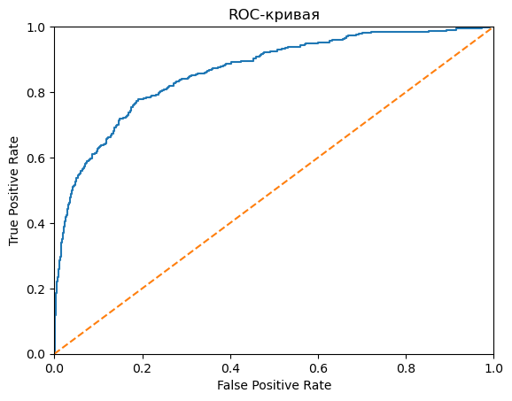

```python
plt.figure()

plt.plot(fpr, tpr)

# ROC-кривая случайной/константной модели
plt.plot([0, 1], [0, 1], linestyle='--')

plt.xlim([0,1])
plt.ylim([0,1])

plt.xlabel('False Positive Rate')
plt.ylabel('True Positive Rate')
plt.title('ROC-кривая')
plt.show()
```

ROC_AUC найденной модели превышает значение метрики константной и случайной модели, значит можно делать вывод об адекватности модели.

**ВЫВОД** : Таким образом, проведено исследование данных, подобрана модель, выдающая оптимальные показатели f1 и roc-auc, на основе которой можно прогнозировать отток клиентов. Модель прошла проверку на адекватность.

## Чек-лист готовности проекта

- [x] Jupyter Notebook открыт
- [x] Весь код выполняется без ошибок
- [x] Ячейки с кодом расположены в порядке исполнения
- [x] Выполнен шаг 1: данные подготовлены
- [x] Выполнен шаг 2: задача исследована
  - [x] Исследован баланс классов
  - [x] Изучены модели без учёта дисбаланса
  - [x] Написаны выводы по результатам исследования
- [x] Выполнен шаг 3: учтён дисбаланс
  - [x] Применено несколько способов борьбы с дисбалансом
  - [x] Написаны выводы по результатам исследования
- [x] Выполнен шаг 4: проведено тестирование
- [x] Удалось достичь *F1*-меры не менее 0.59
- [x] Исследована метрика *AUC-ROC*